# SFT REPORT

**DEEPAK BOGATI (6066481)**

**SUBMITTED TO Ellen Werner, Mona Lütjens, Annette Scheider**

# INTRODUCTION

Python is a programming language that is widely used in the software industry and academia. It is known for its simplicity, readability, and flexibility, which make it a popular choice for beginners and experienced programmers alike. Python has a large and active community of users, which has contributed to the development of a wide range of libraries and frameworks that support a variety of programming tasks, including data analysis, machine learning, and scientific computing. In this project, we are analyzing a Multibeam and single beam data form DV Ocean survey done on 2nd of july 2021 using python in jupiternote book.

**Importing Necessary Liberaries**

```python
import numpy as np
import pandas as pd
import matplotlib.pyplot as plt
from shapely.geometry import Polygon
```

# sample 1

**Also removed the outliers form the height data for final vertical(z) data for low frequancy data**

```python
#LfL1 (short form for lowfrequensy SBES data for line 1)
df = pd.read_csv('test.csv')
#print(df.head())
# Extract the XYZ coordinates from the DataFrame
#x = df['Footprint X']
#y = df['Footprint Y']
#z = df['Footprint Z']
df
```

[output not shown]

695552 rows × 1 columns

```python
df1
```

|  | #Date Time | Footprint X | Footprint Y | Footprint Z |
| --- | --- | --- | --- | --- |
| 0 | 2021-07-02 14:06:35.697 | 568995.323 | 5931523.039 | 7.401 |
| 1 | 2021-07-02 14:06:35.785 | 568995.393 | 5931523.251 | 7.399 |
| 2 | 2021-07-02 14:06:35.874 | 568995.476 | 5931523.463 | 7.397 |
| 3 | 2021-07-02 14:06:35.963 | 568995.541 | 5931523.712 | 7.905 |
| 4 | 2021-07-02 14:06:36.051 | 568995.625 | 5931523.920 | 7.903 |
| ... | ... | ... | ... | ... |
| 1949 | 2021-07-02 14:09:29.211 | 569535.836 | 5931626.613 | 4.948 |
| 1950 | 2021-07-02 14:09:29.300 | 569536.122 | 5931626.647 | 4.940 |
| 1951 | 2021-07-02 14:09:29.388 | 569536.405 | 5931626.689 | 4.974 |
| 1952 | 2021-07-02 14:09:29.477 | 569536.692 | 5931626.753 | 4.962 |
| 1953 | 2021-07-02 14:09:29.565 | 569536.975 | 5931626.798 | 4.954 |

1954 rows × 4 columns

```python
df2
```

|  | #Date Time | Footprint X | Footprint Y | Footprint Z |
| --- | --- | --- | --- | --- |
| 0 | 2021-07-02 14:06:35.698 | 568995.238 | 5931523.007 | 7.717 |
| 1 | 2021-07-02 14:06:35.786 | 568995.307 | 5931523.219 | 7.714 |
| 2 | 2021-07-02 14:06:35.875 | 568995.390 | 5931523.441 | 7.662 |
| 3 | 2021-07-02 14:06:35.963 | 568995.474 | 5931523.650 | 7.661 |
| 4 | 2021-07-02 14:06:36.051 | 568995.558 | 5931523.858 | 7.678 |
| ... | ... | ... | ... | ... |
| 1949 | 2021-07-02 14:09:29.211 | 569535.731 | 5931626.592 | 4.903 |
| 1950 | 2021-07-02 14:09:29.300 | 569536.017 | 5931626.636 | 4.895 |
| 1951 | 2021-07-02 14:09:29.388 | 569536.300 | 5931626.669 | 4.909 |
| 1952 | 2021-07-02 14:09:29.477 | 569536.587 | 5931626.733 | 4.898 |
| 1953 | 2021-07-02 14:09:29.565 | 569536.870 | 5931626.778 | 4.909 |

1954 rows × 4 columns

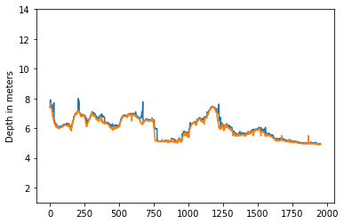

```
0.11097031729785035
```

```python
# Loading the data into a data frame
df1 = pd.read_csv('LfL1.csv')
df2 = pd.read_csv('HfL1.csv')

# Extracting the columns to be plotted
low = df['Footprint Z']
high = df2['Footprint Z']
low.mean()

plt.plot(low)
plt.plot(high)
plt.ylim(1, 14)

# Adding a label to the y-axis
plt.ylabel('Depth in meters')

# Show the plot
plt.show()
thickness = df["Footprint Z"] - df2["Footprint Z"]
thickness = thickness.mean()
thickness
```

```python
df1
```

|  | #Date Time | Footprint X | Footprint Y | Footprint Z |
| --- | --- | --- | --- | --- |
| 0 | 2021-07-02 14:06:35.697 | 568995.323 | 5931523.039 | 7.401 |
| 1 | 2021-07-02 14:06:35.785 | 568995.393 | 5931523.251 | 7.399 |
| 2 | 2021-07-02 14:06:35.874 | 568995.476 | 5931523.463 | 7.397 |
| 3 | 2021-07-02 14:06:35.963 | 568995.541 | 5931523.712 | 7.905 |
| 4 | 2021-07-02 14:06:36.051 | 568995.625 | 5931523.920 | 7.903 |
| ... | ... | ... | ... | ... |
| 1949 | 2021-07-02 14:09:29.211 | 569535.836 | 5931626.613 | 4.948 |
| 1950 | 2021-07-02 14:09:29.300 | 569536.122 | 5931626.647 | 4.940 |
| 1951 | 2021-07-02 14:09:29.388 | 569536.405 | 5931626.689 | 4.974 |
| 1952 | 2021-07-02 14:09:29.477 | 569536.692 | 5931626.753 | 4.962 |
| 1953 | 2021-07-02 14:09:29.565 | 569536.975 | 5931626.798 | 4.954 |

1954 rows × 4 columns

```python
a = low.mean()
b = high.mean()
a-b
```

```
0.11097031729785822
```

**The approximate bulk density of wet clay that is commonly used in normal-weight concrete is between 1240-1410 kg/m3. considering 1300kg/m3 density for the sample sediment**

```python
#area of the target survey areas imported from Qimera.
area1 = 8050.50
area2 = 5443.01
area3 = 1423.81
area4 = 393.31
area5 = 12155.63
```

```python
#Calculation of sediment mass per unit area.
density = 1300
volume = area1 * thickness
mass = density*volume
mass
sediment_mass_per_unit_area = mass/area1
sediment_mass_per_unit_area
```

```
144.26141248720546
```

# Sample 2

**Importing x,y,z Low Frequency singlebeam data form qimera for location/Line 2 and**

**Also removed the outliers form the height data for final vertical(z) data for low frequancy data**

```python
df3 = pd.read_csv('LfL2.csv')
df4 = pd.read_csv('HfL2.csv')
df3
```

|  | #Date Time | Footprint X | Footprint Y | Footprint Z |
| --- | --- | --- | --- | --- |
| 0 | 2021-07-02 13:55:45.165 | 570296.771 | 5929320.827 | 7.530 |
| 1 | 2021-07-02 13:55:45.255 | 570296.774 | 5929321.205 | 7.530 |
| 2 | 2021-07-02 13:55:45.342 | 570296.774 | 5929321.570 | 7.507 |
| 3 | 2021-07-02 13:55:45.430 | 570296.784 | 5929321.938 | 7.510 |
| 4 | 2021-07-02 13:55:45.519 | 570296.799 | 5929322.321 | 7.479 |
| ... | ... | ... | ... | ... |
| 1696 | 2021-07-02 13:58:16.786 | 570307.263 | 5929973.345 | 6.878 |
| 1697 | 2021-07-02 13:58:16.874 | 570307.191 | 5929973.717 | 6.876 |
| 1698 | 2021-07-02 13:58:16.964 | 570307.118 | 5929974.086 | 7.128 |
| 1699 | 2021-07-02 13:58:17.052 | 570307.035 | 5929974.458 | 7.130 |
| 1700 | 2021-07-02 13:58:17.138 | 570306.975 | 5929974.824 | 7.247 |

1701 rows × 4 columns

```python
df4
```

|  | #Date Time | Footprint X | Footprint Y | Footprint Z |
| --- | --- | --- | --- | --- |
| 0 | 2021-07-02 13:55:45.165 | 570296.787 | 5929320.722 | 7.496 |
| 1 | 2021-07-02 13:55:45.255 | 570296.790 | 5929321.099 | 7.477 |
| 2 | 2021-07-02 13:55:45.342 | 570296.790 | 5929321.464 | 7.473 |
| 3 | 2021-07-02 13:55:45.430 | 570296.801 | 5929321.843 | 7.376 |
| 4 | 2021-07-02 13:55:45.519 | 570296.816 | 5929322.216 | 7.375 |
| ... | ... | ... | ... | ... |
| 1696 | 2021-07-02 13:58:16.786 | 570307.297 | 5929973.243 | 6.844 |
| 1697 | 2021-07-02 13:58:16.874 | 570307.235 | 5929973.604 | 7.122 |
| 1698 | 2021-07-02 13:58:16.964 | 570307.152 | 5929973.985 | 7.124 |
| 1699 | 2021-07-02 13:58:17.051 | 570307.079 | 5929974.355 | 7.246 |
| 1700 | 2021-07-02 13:58:17.138 | 570307.008 | 5929974.722 | 7.242 |

1701 rows × 4 columns

[figure not shown]

```
0.23280834803056988
```

```python
# Extracting the columns to be plotted
low = df3['Footprint Z']
high = df4['Footprint Z']
# Adding a label to the y-axis
plt.ylim(1, 14)

plt.ylabel('Depth in meters')
plt.xlabel('sounding samples')

plt.plot(low)
plt.plot(high)

plt.legend(["High Frequency", "Low Frequency"], loc ="lower right")

# Show the plot
plt.show()
thickness = df3["Footprint Z"] - df4["Footprint Z"]
thickness = thickness.mean()
thickness
```

```python
#Calculation of sediment mass per unit area.
density = 1300
volume = area2 * thickness
mass = density*volume
sediment_mass_per_unit_area = mass/area2
sediment_mass_per_unit_area
```

```
302.65085243974085
```

```python
a = low.mean()
b = high.mean()
#a
```

# Sample 3

**Importing x,y,z Low Frequency singlebeam data form qimera for location/Line 3 and**

**Also removed the outliers form the height data for final vertical(z) data for low frequancy data**

[figure not shown]

```
0.15812533814247046
```

```python
df3 = pd.read_csv('LfL3.csv')
df4 = pd.read_csv('HfL3.csv')
df3
df4

# Extracting the columns to be plotted
low = df3['Footprint Z']
high = df4['Footprint Z']
# Adding a label to the y-axis
plt.ylim(1, 8)

plt.ylabel('Depth in meters')
plt.xlabel('sounding samples')

plt.plot(low)
plt.plot(high)

plt.legend(["High Frequency", "Low Frequency"], loc ="lower right")

# Show the plot
plt.show()
thickness = df3["Footprint Z"] - df4["Footprint Z"]
thickness = thickness.mean()
thickness
```

```python
a = low.mean()
b = high.mean()
#b
```

```python
#Calculation of sediment mass per unit area.
density = 1300
volume = area3 * thickness
mass = density*volume
sediment_mass_per_unit_area = mass/area3
sediment_mass_per_unit_area
```

```
205.5629395852116
```

# Sample 4

**Importing x,y,z Low Frequency singlebeam data form qimera for location/Line 4 and**

**Also removed the outliers form the height data for final vertical(z) data for low frequancy data**

[figure not shown]

```
0.1426304627249356
```

```python
df3 = pd.read_csv('LfL4.csv')
df4 = pd.read_csv('HfL4.csv')
#df3
#df4

# Extracting the columns to be plotted
low = df3['Footprint Z']
high = df4['Footprint Z']
# Adding a label to the y-axis
plt.ylim(1, 7)

plt.ylabel('Depth in meters')
plt.xlabel('sounding samples')

plt.plot(low)
plt.plot(high)

plt.legend(["High Frequency", "Low Frequency"], loc ="lower right")

# Show the plot
plt.show()
thickness = df3["Footprint Z"] - df4["Footprint Z"]
thickness = thickness.mean()
thickness
```

```python
#Calculation of sediment mass per unit area.
density = 1300
volume = area4 * thickness
mass = density*volume
sediment_mass_per_unit_area = mass/area4
sediment_mass_per_unit_area
```

```
185.41960154241627
```

```python
a = low.mean()
b = high.mean()
#a
```

# Sample 5

**Importing x,y,z Low and high Frequency singlebeam data form qimera for location/Line 5 and**

**Also removed the outliers form the height data for final vertical(z) data for low frequancy data**

[figure not shown]

```
0.8340356943669817
```

```python
df3 = pd.read_csv('LfL5.csv')
df4 = pd.read_csv('HfL5.csv')
df3
df4

# Extracting the columns to be plotted
low = df3['Footprint Z']
high = df4['Footprint Z']
# Adding a label to the y-axis
plt.ylim(1, 14)

plt.ylabel('Depth in meters')
plt.xlabel('sounding samples')

plt.plot(low)
plt.plot(high)

plt.legend(["High Frequency", "Low Frequency"], loc ="lower right")

# Show the plot
plt.show()
thickness = df3["Footprint Z"] - df4["Footprint Z"]
thickness = thickness.mean()
thickness
```

```python
#Calculation of sediment mass per unit area.
density = 1300
volume = area5 * thickness
mass = density*volume
sediment_mass_per_unit_area = mass/area5
sediment_mass_per_unit_area
```

```
1084.2464026770763
```